# R per l’analisi statistica multivariata

Unità H: simulazioni Monte Carlo

## Numeri pseudo-casuali

I valori generati dal comando `rdist` imitano i risultati di un processo casuale, ma sono in realtà deterministici. I dati sono infatti completamente prevedibili.

Dal momento che i numeri generati sono deterministici, questi vengono chiamati **pseudo-casuali**. Si tratta di sequenze di numeri deterministici che devono sembrare casuali.

È quindi possibile impostare ad uno stato iniziale il generatore di numeri pseudo-casuali attraverso la funzione `set.seed`

```r
set.seed(246135) # Imposto il valore iniziale
rnorm(5, mean = 0, sd = 1)
[1] -0.74639441  0.82913104 -1.11552024  0.03618281 -0.07858270

set.seed(246135) # Re-imposto il valore iniziale
rnorm(5, mean = 0, sd = 1)
[1] -0.74639441  0.82913104 -1.11552024  0.03618281 -0.07858270
```

### Lancio di un dado

Un dado a sei facce rappresenta una variabile casuale $X$ con funzione di probabilità Uniforme Discreta, ovvero

$$\mathbb{P}(X = x) = \frac{1}{6}, \qquad x=1,\dots,6.$$

Per effettuare l’ipotetico lancio di un dado a sei facce, costruiamo un vettore contenente una sequenza di numeri da 1 a 6 corrispondenti ai possibili esiti del lancio.

```r
dice <- 1:6
```

### Il comando `sample`

Per lanciare il dado, si può utilizzare la funzione `sample(x, size, replace, prob)`, che restituisce un campione

1. con reinserimento (`replace=TRUE`);
2. senza reinserimento (`replace=FALSE`);

di ampiezza `size` degli elementi di `x`. Se l’argomento `prob` non viene specificato, la funzione assegna ad ogni elemento di `x` uguale probabilità.

Se volessimo campionare con probabilità non uniformi, dovremmo indicare un vettore di probabilità di lunghezza pari agli elementi di `x`.

```r
sample(x = dice, size = 1)
[1] 6
```

Lanciare il dado $n$ volte consecutive corrisponde a considerare una sequenza di variabili aleatorie $X_1,\dots,X_n$ indipendenti ed identicamente distribuite, ovvero un campionamento **con reinserimento** di ampiezza $n$ dal dado.

```r
n <- 10
x <- sample(dice, size = n, replace = TRUE)
x
 [1] 5 4 4 5 4 6 4 3 4 3
```

### Campionamento senza reinserimento

Se specifichiamo solamente

```r
sample(dice)
[1] 6 1 3 5 4 2
```

otteniamo una **permutazione** casuale degli elementi di `x`, poichè di default `replace=FALSE`.

Ad esempio, per effettuare una ipotetica estrazione del Lotto, si devono estrarre da un’urna 5 numeri, tra l’1 e il 90, senza reinserimento:

```r
sample(1:90, size = 5, replace = FALSE)
[1] 77 83 24 21 62
```

### Simulazioni Monte Carlo (dati continui)

Le realizzazioni delle variabili aleatorie $X_i \overset{\text{iid}}{\sim}\text{N}(0,1)$, per $i=1,\dots,n$ seguono una distribuzione di tipo gaussiano.

Intuitivamente, ci aspettiamo quindi che la densità dell’istogramma costruito sui dati simulati assomigli alla densità teorica della distribuzione.

```r
set.seed(100)
n <- 10^5 # Numero elevato di simulazioni

x <- rnorm(n) # Simulazione delle variabili aleatorie
```

Se costruiamo l’istogramma e sovrapponiamo la curva della densità, notiamo che in effetti le due densità sono molto simili tra loro.

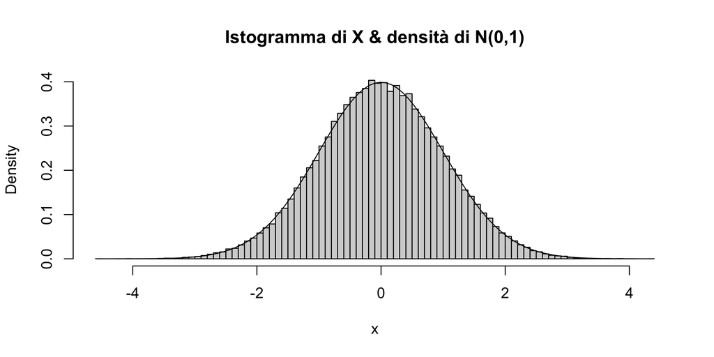

```r
hist(x,
  freq = FALSE,
  breaks = 100,
  main = "Istogramma di X & densità di N(0,1)"
)
curve(dnorm(x), add = TRUE) # add = TRUE implica che la curva viene aggiunta al grafico precedente
```

**Nota**. È molto importante in questo caso usare l’opzione `freq = FALSE`. Lo studente si convinca che non avrebbe senso confrontare $f(x)$ nel caso `freq = TRUE`.

Si noti inoltre che media, mediana e quartili sono prossimi ai valori teorici.

```r
summary(x)
     Min.   1st Qu.    Median      Mean   3rd Qu.      Max.
-4.514481 -0.669717 -0.002325  0.001561  0.673946  4.363243
```

### Simulazioni Monte Carlo (dati discreti)

Siano $X_i \overset{\text{iid}}{\sim}\text{Pois}(10)$, per $i=1,\dots,n$ delle variabili aleatorie di Poisson con media $\lambda = 10$. Confrontiamo quindi la distribuzione di probabilità empirica con quella teorica

```r
n <- 10^5
set.seed(100)
x <- rpois(n, 10) # Simulazione di n variabili Poisson

freq_rel <- table(x) / n # Calcolo delle frequenze relative
```

Il grafico della distribuzione di probabilità si ottiene quindi tramite i seguenti comandi

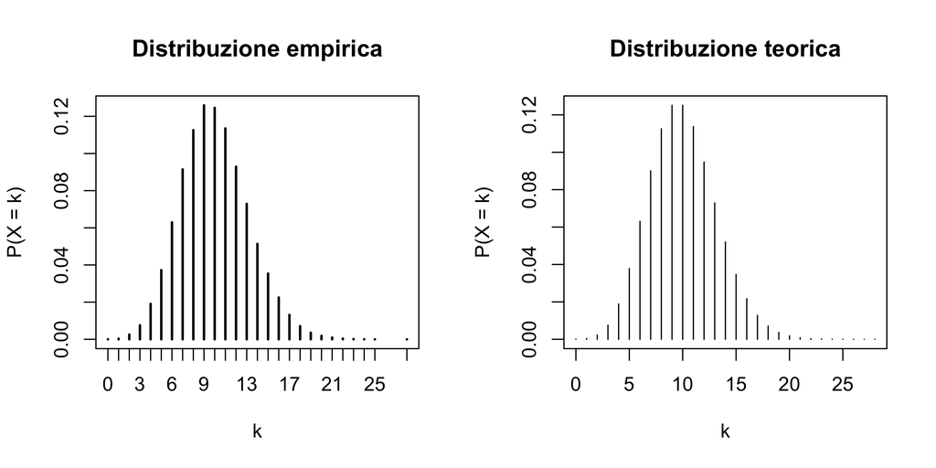

```r
par(mfrow = c(1, 2))
plot(freq_rel, ylab = "P(X = k)", xlab = "k", main = "Distribuzione empirica")
plot(0:28, dpois(0:28, 10), type = "h", ylab = "P(X = k)", xlab = "k", main = "Distribuzione teorica")
```

## Approssimazione di un evento

I risultati del paragrafo precedente sono intuitivamente veri. La loro correttezza deriva però dai risultati della teoria della probabilità.

Sia $X$ una variabile casuale (continua o discreta) e si supponga di voler calcolare la probabilità

$$\mathbb{P}(X \in A),$$
dove $A$ è un evento, ad esempio l’intervallo $A = (0,1]$, il singolo valore $A = 5$, oppure l’intervallo $A = (-\infty, 3]$. Se $X_1,\dots,X_n$ sono delle variabili aleatorie indipendenti ed identicamente distribuite, allora

$$\frac{1}{n}\sum_{i=1}^n \mathbb{I}(X_i \in A) \overset{\text{q.c.}}{\longrightarrow} \mathbb{P}(X_1 \in A), \qquad n \rightarrow \infty.$$
In altri termini, la **proporzione di volte che un evento si verifica nei dati simulati converge** (quasi certamente) **alla probabilità di tale evento**.

### Esempio 1

Se l’evento è $A = (1,2)$ e le variabili aleatorie sono normali standard indipendenti, ovvero $X_i \overset{\text{iid}}{\sim} \text{N}(0,1)$, allora

$$\frac{1}{n}\sum_{i=1}^n \mathbb{I}(X_i \in (1,2)) \overset{\text{q.c.}}{\longrightarrow} \mathbb{P}(X_1 \in (1,2)) = F(2) - F(1) \approx 0.1359051, \qquad n \rightarrow \infty.$$
Verifichiamo in **R** che se $n$ è elevato, allora la proporzione di volte che si verifica un evento è circa pari alla probabilità teorica

```r
n <- 10^4 # n è un numero grande
set.seed(120)
x <- rnorm(n) # Simulo delle variabili aleatorie normali
```

Dopo aver simulato $X_1,\dots,X_n$, ottengo gli indicatori binari $Y_1,\dots,Y_n$, dove $Y_i = \mathbb{I}(X_i \in (1,2))$. Quindi

```r
# Indicatore binario pari 1 se X è compreso tra 1 e 2 e 0 altrimenti
y <- (x > 1) & (x < 2)
```

Infine, confrontiamo il risultato con il valore teorico

```r
# Proporzione di volte che il risultato si è verificato
mean(y) # Equivalente a: sum(y) / n.
[1] 0.1396
pnorm(2) - pnorm(1)
[1] 0.1359051
```

Per apprezzare il concetto di “convergenza”, possiamo visualizzare le medie $\bar{y}_n = 1/n \sum_{i=1}^ny_i$ al variare di $n$

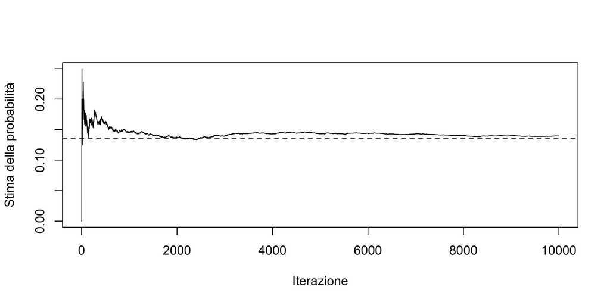

```r
par(mfrow = c(1, 1))
plot(1:n,
  cumsum(y) / 1:n, # Calcolo delle medie al variare di n
  type = "l",
  xlab = "Iterazione",
  ylab = "Stima della probabilità"
)
abline(h = pnorm(2) - pnorm(1), lty = 2) # Disegna una linea orizzontale
```

### Esempio 2

La simulazione dell’esempio precedente è poco “utile”, nel senso che è possibile calcolare $\mathbb{P}(X \in (1,2))$, con $X \sim \text{N}(0,1)$, senza dover ricorrere alla simulazione.

In alcuni contesti, tuttavia, la simulazione facilita moltissimo il calcolo. Per esempio, si supponga che
$$A = \{\text{"Numeri naturali divisibili per 7"} \}, \qquad X \sim \text{Pois}(150).$$
Vogliamo calcolare $\mathbb{P}(X \in A)$, ovvero la probabilità che $X$ sia divisibile per $7$.

In **R** possiamo quindi svolgere le seguenti operazioni:

```r
n <- 10^5
set.seed(160)

# Simulo le variabili di Poisson e derivo gli indicatori binari
x <- rpois(n, 150)
y <- (x %% 7) == 0 # Il simbolo %% è la funzione "resto della divisione"
```

Un’approssimazione della probabilità cercata è quindi pari a

```r
mean(y)
[1] 0.14161
```

## La legge dei grandi numeri

Consideriamo ora un risultato teorico di grande importanza, ovvero la legge dei grandi numeri.

Sia $X$ una variabile casuale (continua o discreta) e si supponga di voler calcolare il valore atteso

$$\mathbb{E}(g(X)) < \infty,$$
dove $g(\cdot)$ è una funzione qualsiasi. Se $X_1,\dots,X_n$ sono delle variabili aleatorie indipendenti ed identicamente distribuite, allora

$$\frac{1}{n}\sum_{i=1}^n g(X_i) \overset{\text{q.c.}}{\longrightarrow} \mathbb{E}(g(X)), \qquad n \rightarrow \infty.$$

### Esempio 1

Se per esempio $X_i \overset{\text{iid}}{\sim} \text{Gamma}(\alpha, \beta)$, allora

$$\frac{1}{n}\sum_{i=1}^n X_i \overset{\text{q.c.}}{\longrightarrow} \frac{\alpha}{\beta}.$$

In **R** possiamo verificare questo teorema come segue

```r
# Definizione dei parametri
alpha <- 3
beta <- 2

n <- 10^5
x <- rgamma(n, shape = alpha, rate = beta)

mean(x) # Stima empirica del valore atteso di X
[1] 1.499245
alpha / beta # Valore atteso teorico di X
[1] 1.5
```

### Esempio 2

Nell’esempio precedente, il valore atteso che abbiamo approssimato era facilmente ottenibile tramite calcoli teorici. Tuttavia, questo non sempre accade. Per esempio, si supponga di voler calcolare

$$\mathbb{E}(\sin(X^2)), \qquad X \sim \text{N}(0,1).$$
Il calcolo di questo valore atteso si ottiene semplicemente come segue

```r
n <- 10^5
x <- rnorm(n)
mean(sin(x^2))
[1] 0.354459
```

## Teorema del limite centrale

Il teorema del limite centrale, in una delle sue versioni più elementari, afferma che se $X_1,\dots,X_n$ sono delle variabili aleatorie indipendenti di media $E(X_1) = \mu < \infty$ e varianza $\sigma^2 < \infty$, allora vale che

$$\frac{\bar{X} - \mu}{\sigma/\sqrt{n}} = \frac{\bar{X} - E(\bar{X})}{\text{var}(\bar{X})^{1/2}} \overset{\text{d}}{\longrightarrow} \text{N}(0,1).$$

### Esempio 1

Prendiamo come esempio delle variabili esponenziali indipendenti $X_1,\dots,X_n$ di parametro $\lambda$, la cui media è $\mathbb{E}(X_1) = 1/\lambda$ e varianza $\sigma^2 = 1/\lambda^2$. Il teorema del limite centrale afferma che

$$Z_n = \lambda \sqrt{n} ( \bar{X} - 1/\lambda) \overset{\text{d}}{\longrightarrow} \text{N}(0,1), \qquad n \rightarrow \infty.$$
Per verificare empiricamente questa proprietà, ad esempio per $\lambda = 3$, possiamo simulare varie volte la variabile aleatoria $Z_n$ per valori di $n$ estremamente elevati e verificare che la sua distribuzione è “circa” quella di una normale standard.

```r
set.seed(156)

n <- 10^4 # Numerosità campionaria elevata
R <- 10^4 # Numero di simulazioni effettuate
lambda <- 3

# Estrazioni casuali da una variabile aleatoria Z_n
Z_n <- replicate(R, lambda * sqrt(n) * (mean(rexp(n = n, rate = lambda)) - 1 / lambda))
```

Una volta simulati i valori dalla variabile $Z_n$, la possiamo rappresentare graficamente

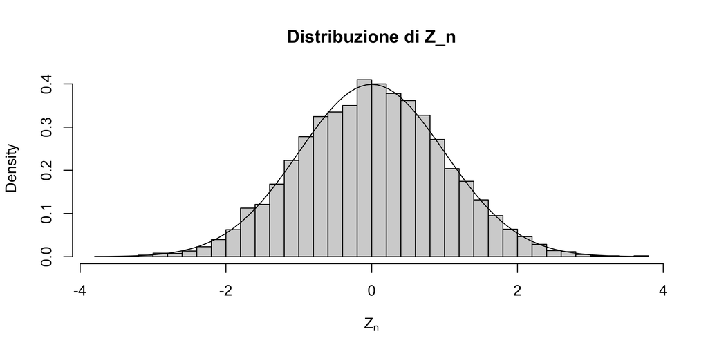

```r
hist(Z_n,
  freq = FALSE,
  main = "Distribuzione di Z_n", xlab = expression(Z[n]),
  breaks = 50
)
curve(dnorm(x, mean = 0, sd = 1), add = TRUE)
```

### Esempio 2

Non tutti i valori di $n$ conducono ad una distribuzione di $Z_n$ indistinguibile da una distribuzione normale standard. Per esempio, si consideri il caso $n = 5$

```r
set.seed(156)

n <- 5 # Numerosità campionaria bassa
R <- 10^4 # Numero di simulazioni effettuate
lambda <- 3

# Estrazioni casuali da una variabile aleatoria Z_n
Z_n <- replicate(R, lambda * sqrt(n) * (mean(rexp(n = n, rate = lambda)) - 1 / lambda))
```

Il grafico successivo illustra un caso in cui l’approssimazione normale non sembra essere molto buona.

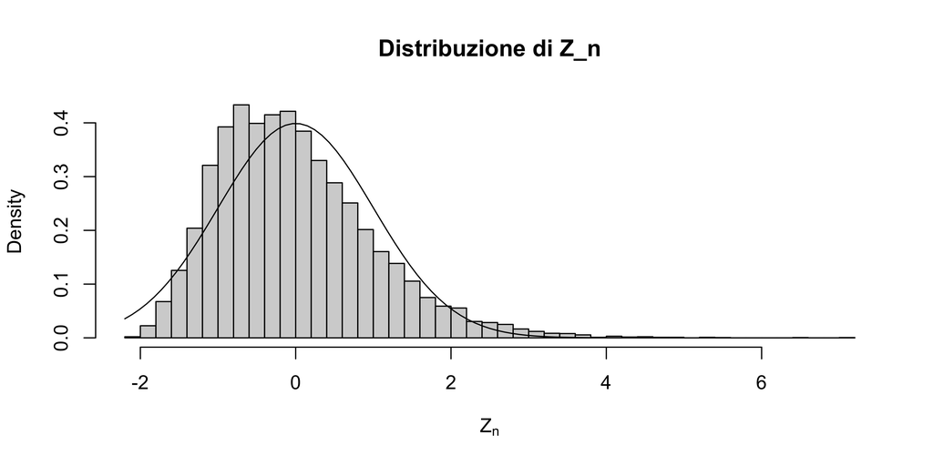

```r
hist(Z_n,
  freq = FALSE,
  main = "Distribuzione di Z_n", xlab = expression(Z[n]),
  breaks = 50
)
curve(dnorm(x, mean = 0, sd = 1), add = TRUE)
```

## QQ-plot

Un modo differente per verificare empiricamente se la distribuzione di una variabile $X$ è “simile” a quella di una Gaussiana, è tramite il cosiddetto **QQ-plot**. In pratica, si confrontano in un diagramma a dispersione i quantili empirici con i quantili teorici, ovvero

$$\mathcal{Q}_p = \text{(Quantili empirici)}, \quad \text{ vs } \quad z_p = \text{(Quantili teorici della normale standard)}.$$
su una griglia di valori $p$ di lunghezza $n$.

Innanzitutto, generiamo dei dati fittizi e la la griglia di valori $p$.

```r
set.seed(123)
n <- 50
x <- rnorm(n, mean = 10, sd = 5)

p <- ppoints(n) # Comando che genera una griglia di valori p
p
 [1] 0.01 0.03 0.05 0.07 0.09 0.11 0.13 0.15 0.17 0.19 0.21 0.23 0.25 0.27 0.29 0.31 0.33 0.35 0.37
[20] 0.39 0.41 0.43 0.45 0.47 0.49 0.51 0.53 0.55 0.57 0.59 0.61 0.63 0.65 0.67 0.69 0.71 0.73 0.75
[39] 0.77 0.79 0.81 0.83 0.85 0.87 0.89 0.91 0.93 0.95 0.97 0.99
```

Calcoliamo quindi i quantili teorici e quelli empirici come segue:

```r
z_p <- qnorm(p) # Quantili teorici della normale standard
Q_p <- quantile(x, probs = p, type = 5) # Quantili empirici dei dati
```

Il cosiddetto **QQ-plot** si ottiene quindi con i comandi seguenti. In caso i dati assomiglino ad una normale, allora i valori dovrebbero essere allineati lungo una retta.

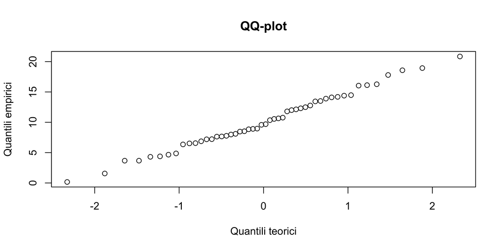

```r
plot(z_p, Q_p, main = "QQ-plot", xlab = "Quantili teorici", ylab = "Quantili empirici")
```

In **R** in realtà esiste un comando che svolge direttamente queste operazioni per noi, ovvero

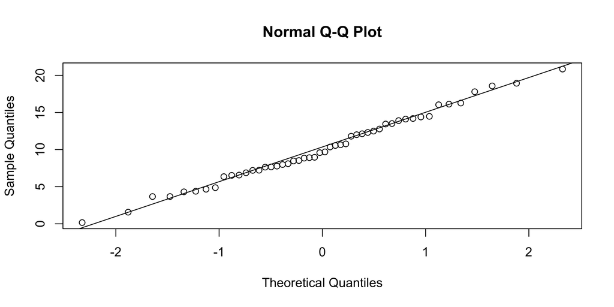

```r
qqnorm(x) # Grafico ottenuto in precedenza
qqline(x, qtype = 5) # Aggiunta della retta "teorica"
```

Come si può leggere dalla documentazione, `qqline` aggiunge la retta passante per i punti $(z_{0.25},\mathcal{Q}_{0.25})$ e $(z_{0.75},\mathcal{Q}_{0.75})$, che può essere considerata una versione robusta della retta ai minimi quadrati.

### La funzione `qqnorm` per dati non gaussiani

Se i dati non provengono da una distribuzione normale, allora il **QQ-plot** è in grado segnalarcelo.

Prendiamo in considerazione delle variabili aleatorie aventi distribuzione esponenziale di parametro $\lambda = 10$.

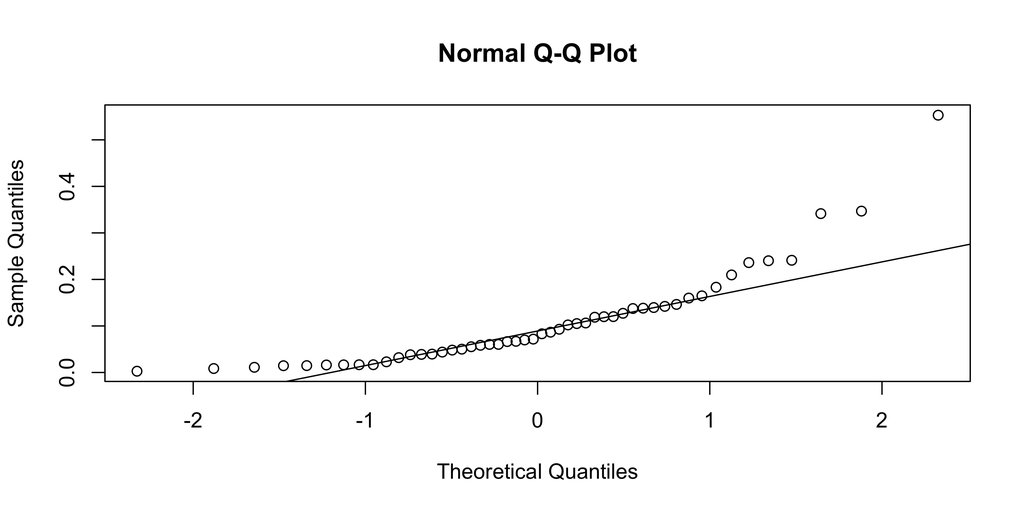

```r
set.seed(150)
x <- rexp(n, rate = 10) # Genero n osservazioni esponenziali indipendenti

## QQ-plot
qqnorm(x)
qqline(x)
```

Questo **QQ-plot** evidenza chiaramente uno scostamente dalla distribuzione gaussiana, dato che i punti sono ben distanti dalla linea disegnata da `qqline`.

### Nota a margine

Supponiamo di non conoscere il funzionamento di una funzione, ad esempio `qqline`.

Per conoscerne il funzionamento preciso, è possibile scriverla nel terminale, il quale restituirà la sua definizione.

```r
qqline
function (y, datax = FALSE, distribution = qnorm, probs = c(0.25,
    0.75), qtype = 7, ...)
{
    stopifnot(length(probs) == 2, is.function(distribution))
    y <- quantile(y, probs, names = FALSE, type = qtype, na.rm = TRUE)
    x <- distribution(probs)
    if (datax) {
        slope <- diff(x)/diff(y)
        int <- x[1L] - slope * y[1L]
    }
    else {
        slope <- diff(y)/diff(x)
        int <- y[1L] - slope * x[1L]
    }
    abline(int, slope, ...)
}
<bytecode: 0x7f8b9e7d34f0>
<environment: namespace:stats>
```